# Lab 8: Assumption-Lean Regression

Causal Machine Learning

Stijn Vansteelandt and Federico Bertoia, Ghent University

2026-04-29

## 0. Introduction

The goal of this lab is to apply **assumption-lean regression** to estimate the effect of a health program on a binary outcome, using the King County 2001 birth data. The key idea is to use a semiparametric model as an **approximation** rather than an assumption, and to estimate the resulting model-free estimand via its efficient influence function combined with machine learning.

### Data

The **King County 2001** dataset contains birth certificate records from 2,500 singleton births in King County, Washington (2001). The program of interest is **First Steps**, a 1989 Washington State initiative aimed at improving maternal and infant health for low-income pregnant women.

[output not shown]

```r
library(SuperLearner)
library(lmtest)
library(sandwich)
library(fastDummies)
library(dplyr)
library(ggplot2)
library(tibble)
library(patchwork)

expit <- function(x) 1 / (1 + exp(-x))
logit <- function(p) log(p / (1 - p))

set.seed(123)

df <- read.table("KingCounty2001.data")
colnames(df) <- c(
  "gender", "plural", "age", "race", "parity", "married",
  "bwt", "smokeN", "drinkN", "firstep", "welfare",
  "smoker", "drinker", "wpre", "wgain", "education", "gestation"
)

glimpse(df)
```

```
## Rows: 2,500
## Columns: 17
## $ gender    <chr> "F", "M", "F", "M", "M", "M", "F", "M", "F", "F", "F", "F", …
## $ plural    <int> 1, 1, 1, 1, 1, 1, 1, 1, 1, 1, 1, 1, 1, 1, 1, 1, 1, 1, 1, 1, …
## $ age       <int> 31, 23, 24, 26, 34, 15, 24, 30, 23, 37, 20, 35, 28, 22, 26, …
## $ race      <chr> "hispanic", "white", "black", "hispanic", "white", "black", …
## $ parity    <int> 4, 0, 1, 2, 0, 0, 4, 1, 0, 2, 0, 0, 0, 0, 3, 0, 2, 2, 1, 0, …
## $ married   <int> 1, 1, 0, 1, 0, 0, 1, 1, 0, 1, 0, 0, 1, 1, 1, 0, 0, 0, 1, 1, …
## $ bwt       <int> 3118, 3466, 3147, 3969, 3005, 2920, 3260, 4451, 3106, 3345, …
## $ smokeN    <int> 0, 0, 0, 0, 0, 0, 0, 0, 0, 0, 0, 0, 0, 0, 0, 0, 4, 0, 0, 0, …
## $ drinkN    <int> 0, 0, 0, 0, 0, 0, 0, 0, 0, 0, 0, 0, 0, 0, 0, 0, 0, 0, 0, 0, …
## $ firstep   <int> 1, 1, 1, 1, 1, 1, 1, 1, 1, 1, 1, 1, 1, 1, 1, 1, 1, 1, 1, 1, …
## $ welfare   <int> 0, 0, 0, 0, 0, 0, 0, 0, 0, 0, 1, 0, 0, 0, 0, 0, 0, 0, 0, 0, …
## $ smoker    <chr> "N", "N", "N", "N", "N", "N", "N", "N", "N", "N", "N", "N", …
## $ drinker   <chr> "N", "N", "N", "N", "N", "N", "N", "N", "N", "N", "N", "N", …
## $ wpre      <int> 122, 160, 150, 175, 123, 180, 190, 160, 90, 186, 160, 100, 1…
## $ wgain     <int> 22, 50, 38, 15, 17, 12, 46, 28, 38, 47, 35, 30, 66, 50, 31, …
## $ education <int> 5, 12, 13, 12, 17, 9, 11, 15, 14, 12, 12, 4, 17, 12, 11, 12,…
## $ gestation <int> 40, 39, 40, 39, 40, 36, 40, 42, 40, 40, 34, 42, 39, 39, 37, …
```

## 1. Data Preparation

We construct the binary outcome (low birth weight), recode categorical variables, and select the confounders, **excluding post-treatment variables** (`smoker`, `drinker`, `wgain`, `gestation`) to avoid mediation and collider bias.

```r
N <- nrow(df)

# Binary outcome: low birth weight (< 2500 g)
df$low_bwt <- as.integer(df$bwt < 2500)

# Recode character variables to numeric
df$gender  <- as.integer(df$gender  == "M")   # 1 = male
df$married <- as.integer(df$married == "Y")   # 1 = married

# Dummy-code race (drop reference category "other")
df <- dummy_cols(df, select_columns = "race",
                 remove_first_dummy = FALSE, remove_selected_columns = TRUE)
df$race_other <- NULL

# Drop variables not used as confounders
df <- df %>%
  select(-plural, -bwt, -smokeN, -drinkN, -welfare, -smoker,
         -drinker, -wgain, -gestation, -parity)

# ── Analysis variables ────────────────────────────────────────────────────────

# Binary exposure: First Steps program participation
Y <- df$low_bwt   # outcome
A <- df$firstep   # exposure
L <- df %>% select(-low_bwt, -firstep)   # baseline confounders

# Continuous exposure: maternal age
y <- df$low_bwt   # outcome
a <- df$age       # exposure
l <- df %>% select(-low_bwt, -firstep, -age)   # baseline confounders
```

## 2. Exploratory Data Analysis

### 2.1 Outcome and exposure distributions

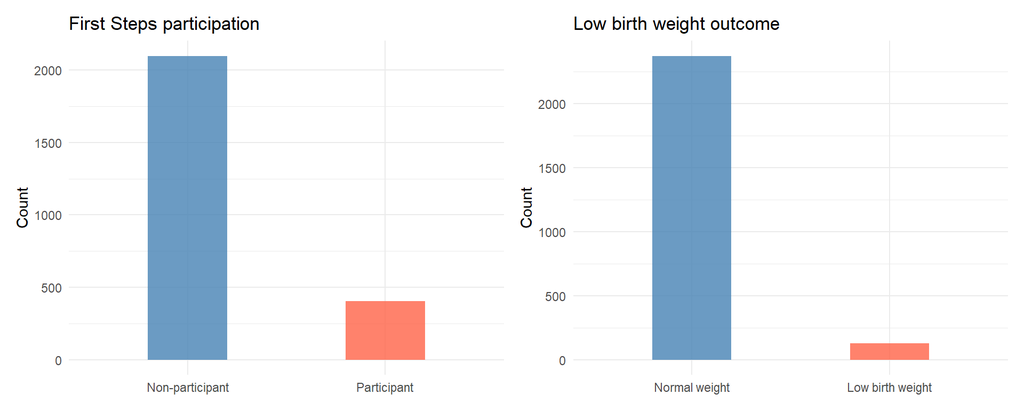

```r
p1 <- df %>%
  mutate(firstep = factor(firstep, labels = c("Non-participant", "Participant"))) %>%
  ggplot(aes(x = firstep, fill = firstep)) +
  geom_bar(alpha = 0.8, width = 0.4) +
  scale_fill_manual(values = c("steelblue", "tomato")) +
  labs(x = NULL, y = "Count", title = "First Steps participation") +
  theme_minimal() +
  theme(legend.position = "none")

p2 <- df %>%
  mutate(low_bwt = factor(low_bwt, labels = c("Normal weight", "Low birth weight"))) %>%
  ggplot(aes(x = low_bwt, fill = low_bwt)) +
  geom_bar(alpha = 0.8, width = 0.4) +
  scale_fill_manual(values = c("steelblue", "tomato")) +
  labs(x = NULL, y = "Count", title = "Low birth weight outcome") +
  theme_minimal() +
  theme(legend.position = "none")

p1 + p2
```

### 2.2 Maternal age distribution

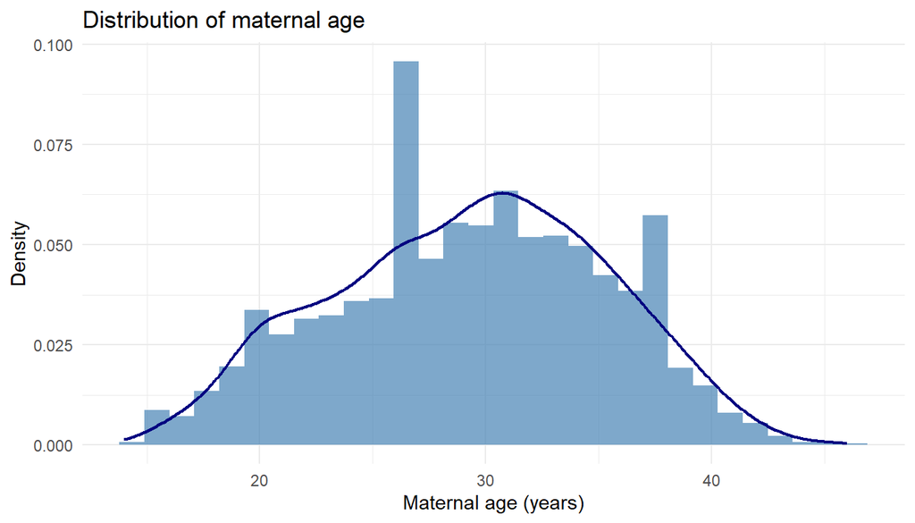

```r
ggplot(df, aes(x = age)) +
  geom_histogram(aes(y = after_stat(density)), bins = 30,
                 fill = "steelblue", alpha = 0.7) +
  geom_density(color = "navy", linewidth = 0.8) +
  labs(x = "Maternal age (years)", y = "Density",
       title = "Distribution of maternal age") +
  theme_minimal()
```

### 2.3 Outcome by First Steps participation

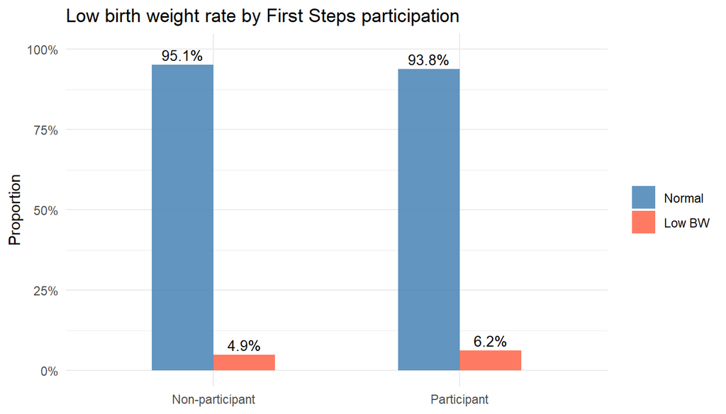

```r
df %>%
  mutate(
    firstep = factor(firstep, labels = c("Non-participant", "Participant")),
    low_bwt = factor(low_bwt, labels = c("Normal", "Low BW"))
  ) %>%
  count(firstep, low_bwt) %>%
  group_by(firstep) %>%
  mutate(prop = n / sum(n)) %>%
  ggplot(aes(x = firstep, y = prop, fill = low_bwt)) +
  geom_col(position = "dodge", alpha = 0.85, width = 0.5) +
  geom_text(aes(label = scales::percent(prop, accuracy = 0.1)),
            position = position_dodge(width = 0.5), vjust = -0.4, size = 3.5) +
  scale_fill_manual(values = c("steelblue", "tomato")) +
  scale_y_continuous(labels = scales::percent, limits = c(0, 1)) +
  labs(x = NULL, y = "Proportion", fill = NULL,
       title = "Low birth weight rate by First Steps participation") +
  theme_minimal()
```

## 3. Super Learner Setup

We use `SuperLearner` to estimate the nuisance functions $\hat{E}(Y \mid A, L)$ (outcome model, $\hat{Y}$) and $\hat{E}(A \mid L)$ (exposure model / propensity score, $\hat{\pi}$). Cross-fitting with 5 folds is used throughout to avoid overfitting bias.

```r
SL.library <- c("SL.glm", "SL.ranger", "SL.earth", "SL.gam")

n_folds <- 5
fold_id <- sample(rep(1:n_folds, length.out = N))
folds   <- split(seq_len(N), fold_id)
```

## 4. Question 1 — AL Linear Regression: First Steps → Low Birth Weight

### 4.1 Relevant confounders

Possible **missing confounders** include household income (only proxied by education) and health insurance status, which affects both eligibility for First Steps and access to prenatal care.

### 4.2 Cross-fitted nuisance estimates

We estimate two nuisance functions via 5-fold cross-fitting:

- $\hat{Y}(L) = \hat{E}[Y \mid L]$ — outcome regression
- $\hat{\pi}(L) = \hat{P}(A = 1 \mid L)$ — propensity score

```r
AL <- data.frame(A, L)

pi_hat <- rep(NA_real_, N)   # P(A = 1 | L)
y_hat <- rep(NA_real_, N)   # E(Y | L)

for (k in 1:n_folds) {

  test  <- folds[[k]]
  train <- setdiff(seq_len(N), test)

  outcome_model_y <- SuperLearner(
    Y          = Y[train],
    X          = L[train, ],
    SL.library = SL.library,
    family     = binomial(),
    method     = "method.NNLS",
    cvControl  = list(V = 5)
  )

  # Propensity score model: P(A = 1 | L)
  propensity_model <- SuperLearner(
    Y          = A[train],
    X          = L[train, ],
    SL.library = SL.library,
    family     = binomial(),
    method     = "method.NNLS",
    cvControl  = list(V = 5)
  )

  pi_hat[test] <- predict(propensity_model, newdata = L[test, ])$pred
  y_hat[test] <- predict(outcome_model_y, newdata = L[test, ])$pred
}

# Clip to avoid numerical instability
pi_hat <- pmax(0.01, pmin(0.99, pi_hat))
y_hat <- pmax(0.01, pmin(0.99, y_hat))
```

### 4.3 Assumption-lean estimator via `lm` (sandwich SE)

Regress the residual outcome $(Y - \hat{Y})$ onto the residual exposure $(A - \hat{\pi})$ with no intercept.

```r
lm_rd1        <- lm(I(Y - y_hat) ~ -1 + I(A - pi_hat))
lm_rd1_result <- coeftest(lm_rd1, vcov = sandwich)

beta_rd1_lm <- lm_rd1_result[1, 1]
se_rd1_lm   <- lm_rd1_result[1, 2]
```

### 4.4 Assumption-lean estimator via EIF (by hand)

```r
beta_rd1_eif <- mean((A - pi_hat) * (Y - y_hat)) / mean((A - pi_hat)^2)

eif_rd1    <- (A - pi_hat) * (Y - y_hat - beta_rd1_eif * (A - pi_hat)) / mean((A - pi_hat)^2)
se_rd1_eif <- sd(eif_rd1) / sqrt(N)
```

### 4.5 Results

```r
results_q1 <- tibble(
  Method   = c("EIF", "LM (sandwich)"),
  Estimate = c(beta_rd1_eif, beta_rd1_lm),
  SE       = c(se_rd1_eif,   se_rd1_lm),
  CI_Lower = Estimate - 1.96 * SE,
  CI_Upper = Estimate + 1.96 * SE
)

knitr::kable(results_q1, digits = 4,
             caption = "Q1 — Risk difference: First Steps on low birth weight")
```

Q1 — Risk difference: First Steps on low birth weight

| Method | Estimate | SE | CI_Lower | CI_Upper |
| --- | --- | --- | --- | --- |
| EIF | 0.0053 | 0.0145 | -0.0231 | 0.0338 |
| LM (sandwich) | 0.0053 | 0.0145 | -0.0231 | 0.0337 |

> **Interpretation (assuming constant effect):** The estimate $\hat\beta$ represents the overlap-weighted average risk difference $E\{w(L)\beta(L)\}/E\{w(L)\}$. If $\beta(L) = \beta$ (constant), this equals the population average treatment effect. Participation in First Steps is estimated to **increase** the probability of low birth weight by approximately 0.53 percentage points; however, this estimate is **not statistically significant** (95% CI includes 0).

> **If** $\beta(L)$ is not constant: The effect of First Steps likely varies by individual characteristics (e.g. younger or less-educated mothers may benefit more). The estimand is then a weighted average that gives higher weight to covariate strata with greater treatment variability—those where we learn most from the data.

> **Advantage over standard linear regression:** If the outcome model is misspecified, the standard OLS coefficient no longer captures the association of interest. The assumption-lean estimator remains interpretable regardless of misspecification, and valid data-adaptive inference is obtained through the EIF.

## 5. Question 2 — Weighted Baseline Characteristics

Assumption-lean regression implicitly weights participants by $w(L) = P(A=1 \mid L)\,P(A=0 \mid L)$. It is therefore informative to report **weighted summary statistics** to characterize the effective study population.

### 5.1 EIF-based weighted summary

The efficient influence function of $\theta = E\{P(A=1|L)P(A=0|L)\,X\}/E\{P(A=1|L)P(A=0|L)\}$ is:

$$\Phi(\theta) = -\frac{\bigl[P(A=1|L)P(A=0|L) + \{1 - 2P(A=1|L)\}\{A -
P(A=1|L)\}\bigr](X - \theta)}{E\{P(A=1|L)P(A=0|L)\}}.$$

It can be shown that $P(A=1|L)P(A=0|L) + \{1-2\pi\}(A-\pi) = (A-\pi)^2$, so the debiased estimator simplifies to:

$$\hat\theta = \frac{\sum_{i=1}^n (A_i - \hat\pi_i)^2\,X_i}{\sum_{i=1}^n
(A_i - \hat\pi_i)^2},
\qquad
\widehat{\mathrm{SE}}(\hat\theta) =
\frac{1}{\sqrt{n}}\,\mathrm{sd}\!\left(\frac{(A_i - \hat\pi_i)^2\,(X_i -
\hat\theta)}{mean(\hat\pi(1-\hat\pi))}\right).$$

```r
weighted_summary <- do.call(rbind, lapply(names(L), function(varname) {
  X <- L[[varname]]
  if (!is.numeric(X)) return(NULL)

  w_mean <- mean((A - pi_hat)^2 * X) / mean((A - pi_hat)^2)
  eif_w  <- (A - pi_hat)^2 * (X - w_mean) / mean(pi_hat * (1 - pi_hat))
  w_se   <- sd(eif_w) / sqrt(N)

  data.frame(
    Variable      = varname,
    Weighted_Mean = round(w_mean, 3),
    SE            = round(w_se,   3),
    CI_Lower      = round(w_mean - 1.96 * w_se, 3),
    CI_Upper      = round(w_mean + 1.96 * w_se, 3)
  )
}))

knitr::kable(weighted_summary,
             caption = "Q2 — Overlap-weighted baseline characteristics")
```

Q2 — Overlap-weighted baseline characteristics

| Variable | Weighted_Mean | SE | CI_Lower | CI_Upper |
| --- | --- | --- | --- | --- |
| gender | 0.529 | 0.021 | 0.487 | 0.571 |
| age | 26.185 | 0.274 | 25.647 | 26.722 |
| married | 0.000 | 0.000 | 0.000 | 0.000 |
| wpre | 150.060 | 1.682 | 146.763 | 153.356 |
| education | 12.408 | 0.118 | 12.176 | 12.640 |
| race_asian | 0.137 | 0.015 | 0.107 | 0.166 |
| race_black | 0.134 | 0.013 | 0.109 | 0.160 |
| race_hispanic | 0.184 | 0.015 | 0.156 | 0.213 |
| race_white | 0.526 | 0.021 | 0.484 | 0.567 |

### 5.3 Classic (unweighted) summary for comparison

```r
classic_summary <- do.call(rbind, lapply(names(L), function(varname) {
  X <- L[[varname]]
  if (!is.numeric(X)) return(NULL)

  c_mean <- mean(X)
  c_se   <- sd(X) / sqrt(N)

  data.frame(
    Variable     = varname,
    Classic_Mean = round(c_mean, 3),
    SE           = round(c_se,   3),
    CI_Lower     = round(c_mean - 1.96 * c_se, 3),
    CI_Upper     = round(c_mean + 1.96 * c_se, 3)
  )
}))

knitr::kable(classic_summary,
             caption = "Q2 — Unweighted baseline characteristics")
```

Q2 — Unweighted baseline characteristics

| Variable | Classic_Mean | SE | CI_Lower | CI_Upper |
| --- | --- | --- | --- | --- |
| gender | 0.516 | 0.010 | 0.497 | 0.536 |
| age | 29.304 | 0.120 | 29.069 | 29.539 |
| married | 0.000 | 0.000 | 0.000 | 0.000 |
| wpre | 146.944 | 0.692 | 145.588 | 148.300 |
| education | 14.072 | 0.053 | 13.969 | 14.175 |
| race_asian | 0.157 | 0.007 | 0.143 | 0.171 |
| race_black | 0.071 | 0.005 | 0.061 | 0.081 |
| race_hispanic | 0.088 | 0.006 | 0.077 | 0.099 |
| race_white | 0.672 | 0.009 | 0.653 | 0.690 |

> **Interpretation:** Differences between weighted and unweighted means reveal which subpopulation the AL estimator effectively targets. Participants with intermediate propensity scores (neither near 0 nor 1) receive the highest overlap weight, since they carry the most information about the treatment effect.

## 6. Question 3 — AL Linear Regression: Maternal Age → Low Birth Weight

Here the **exposure is continuous** (maternal age). The estimand is:

$$\beta = \frac{E\{\mathrm{Cov}(A, Y \mid L)\}}{E\{\mathrm{Var}(A \mid
L)\}},$$

interpreted as the average change in risk of low birth weight associated with a 1-year increase in maternal age, after adjusting for confounders $L$. This corresponds to a **shift intervention**: if everyone’s age were shifted by $a$ years, the expected outcome would change by $\approx \beta \cdot a$.

### 6.1 Cross-fitted nuisance estimates

We estimate:

- $\hat{Y}_2(l) = \hat{E}[y \mid l]$ — outcome regression
- $\hat{\pi}_2(L) = \hat{E}[a \mid l]$ — conditional mean of age (continuous, so Gaussian family)

```r
al <- data.frame(a, l)

pi2_hat <- rep(NA_real_, N)   # E[a | l]
y2_hat <- rep(NA_real_, N)   # E[y | l]

for (k in 1:n_folds) {

  test  <- folds[[k]]
  train <- setdiff(seq_len(N), test)

  # Exposure model: E[a | l]  (continuous, so Gaussian family)
  exposure_model2 <- SuperLearner(
    Y          = a[train],
    X          = l[train, ],
    SL.library = SL.library,
    family     = gaussian(),
    method     = "method.NNLS",
    cvControl  = list(V = 5)
  )

  outcome_model2_y <- SuperLearner(
    Y          = y[train],
    X          = l[train, ],
    SL.library = SL.library,
    family     = binomial(),
    method     = "method.NNLS",
    cvControl  = list(V = 5)
  )

  pi2_hat[test] <- predict(exposure_model2, newdata = l[test, ])$pred
  y2_hat[test] <- predict(outcome_model2_y,  newdata = l[test, ])$pred
}

y2_hat <- pmax(0.01, pmin(0.99, y2_hat))
```

### 6.2 Estimates

```r
# Via lm with sandwich SE
lm_rd3        <- lm(I(y - y2_hat) ~ -1 + I(a - pi2_hat))
lm_rd3_result <- coeftest(lm_rd3, vcov = sandwich)

beta_rd3_lm <- lm_rd3_result[1, 1]
se_rd3_lm   <- lm_rd3_result[1, 2]

# Via EIF
beta_rd3_eif <- mean((a - pi2_hat) * (y - y2_hat)) / mean((a - pi2_hat)^2)

eif_rd3    <- (a - pi2_hat) * (y - y2_hat - beta_rd3_eif * (a - pi2_hat)) / mean((a - pi2_hat)^2)
se_rd3_eif <- sd(eif_rd3) / sqrt(N)

results_q3 <- tibble(
  Method   = c("EIF", "LM (sandwich)"),
  Estimate = c(beta_rd3_eif, beta_rd3_lm),
  SE       = c(se_rd3_eif,   se_rd3_lm),
  CI_Lower = Estimate - 1.96 * SE,
  CI_Upper = Estimate + 1.96 * SE
)

knitr::kable(results_q3, digits = 5,
             caption = "Q3 — Risk difference: maternal age on low birth weight")
```

Q3 — Risk difference: maternal age on low birth weight

| Method | Estimate | SE | CI_Lower | CI_Upper |
| --- | --- | --- | --- | --- |
| EIF | 0.00108 | 0.00097 | -0.00083 | 0.00299 |
| LM (sandwich) | 0.00108 | 0.00097 | -0.00083 | 0.00299 |

> **Interpretation (shift intervention):** A 1-year increase in maternal age is estimated to change the risk of low birth weight by $\hat\beta \approx 0.0011$ (0.11 percentage points). The 95% confidence interval includes 0, so the association is **not statistically significant**.

## 7. Question 4 — Risk Ratio Scale

We use **assumption-lean log-linear regression**:

$$\log E(Y^a \mid L) = \alpha(L) + \beta a,$$

so that $\mathrm{RR} = e^\beta$.

The debiased estimator regresses the pseudo-outcome

$$\widetilde{Y}^{\log} = \log(\hat{Y}) - \hat{q}^{\log} + \frac{Y -
\hat{Y}}{\hat{Y}}$$

onto $(A - \hat{\pi})$ with no intercept (sandwich SE), where $\hat{q}^{\log}(L) = \hat{E}[\log \hat{Y}(A, L) \mid L]$.

### 7.1 First Steps program

```r
# Step 1: estimate q_log_hat(L) = E[log y_al_hat(A, L) | L] via cross-fitting
q_log_hat <- rep(NA_real_, N)
y_al_hat <- rep(NA_real_, N)   # E[Y | A, L]

for (k in 1:n_folds) {

  test  <- folds[[k]]
  train <- setdiff(seq_len(N), test)

  # Re-fit outcome model on training fold
  outcome_model <- SuperLearner(
    Y          = Y[train],
    X          = AL[train, ],
    SL.library = SL.library,
    family     = binomial(),
    method     = "method.NNLS",
    cvControl  = list(V = 5)
  )

  log_mu_train <- log(predict(outcome_model, newdata = AL[train, ])$pred)

  # Marginalisation model: E[log y_al_hat | L]
  qlog_model <- SuperLearner(
    Y          = log_mu_train,
    X          = L[train, ],
    SL.library = SL.library,
    family     = gaussian(),
    method     = "method.NNLS",
    cvControl  = list(V = 5)
  )

  y_al_hat[test] <- predict(outcome_model,    newdata = AL[test, ])$pred
  q_log_hat[test] <- predict(qlog_model, newdata = L[test, ])$pred
}
y_al_hat <- pmax(0.01, pmin(0.99, y_al_hat))

# Step 2: construct pseudo-outcome and regress
pseudo_log1 <- log(y_al_hat) - q_log_hat + (Y - y_al_hat) / y_al_hat

lm_rr1        <- lm(I(pseudo_log1) ~ -1 + I(A - pi_hat))
lm_rr1_result <- coeftest(lm_rr1, vcov = sandwich)

beta_log1 <- lm_rr1_result[1, 1]
se_log1   <- lm_rr1_result[1, 2]

results_rr1 <- tibble(
  Method   = "LM (sandwich)",
  Estimate = exp(beta_log1),
  SE_log   = se_log1,
  CI_Lower = exp(beta_log1 - 1.96 * se_log1),
  CI_Upper = exp(beta_log1 + 1.96 * se_log1)
)

knitr::kable(results_rr1, digits = 3,
             caption = "Q4 — Risk ratio: First Steps on low birth weight")
```

Q4 — Risk ratio: First Steps on low birth weight

| Method | Estimate | SE_log | CI_Lower | CI_Upper |
| --- | --- | --- | --- | --- |
| LM (sandwich) | 1.927 | 0.43 | 0.83 | 4.476 |

### 7.2 Maternal age

```r
q2_log_hat <- rep(NA_real_, N)
y2_al_hat <- rep(NA_real_, N)   # E[y | a, l]

for (k in 1:n_folds) {

  test  <- folds[[k]]
  train <- setdiff(seq_len(N), test)

  outcome_model2 <- SuperLearner(
    Y          = y[train],
    X          = al[train, ],
    SL.library = SL.library,
    family     = binomial(),
    method     = "method.NNLS",
    cvControl  = list(V = 5)
  )

  log_mu2_train <- log(predict(outcome_model2, newdata = al[train, ])$pred)

  qlog_model2 <- SuperLearner(
    Y          = log_mu2_train,
    X          = l[train, ],
    SL.library = SL.library,
    family     = gaussian(),
    method     = "method.NNLS",
    cvControl  = list(V = 5)
  )

  y2_al_hat[test] <- predict(outcome_model2,  newdata = al[test, ])$pred
  q2_log_hat[test] <- predict(qlog_model2, newdata = l[test, ])$pred
}
y2_al_hat <- pmax(0.01, pmin(0.99, y2_al_hat))

pseudo_log2 <- log(y2_al_hat) - q2_log_hat + (y - y2_al_hat) / y2_al_hat

lm_rr2        <- lm(I(pseudo_log2) ~ -1 + I(a - pi2_hat))
lm_rr2_result <- coeftest(lm_rr2, vcov = sandwich)

beta_log2 <- lm_rr2_result[1, 1]
se_log2   <- lm_rr2_result[1, 2]

results_rr2 <- tibble(
  Method   = "LM (sandwich)",
  Estimate = exp(beta_log2),
  SE_log   = se_log2,
  CI_Lower = exp(beta_log2 - 1.96 * se_log2),
  CI_Upper = exp(beta_log2 + 1.96 * se_log2)
)

knitr::kable(results_rr2, digits = 4,
             caption = "Q4 — Risk ratio: maternal age on low birth weight")
```

Q4 — Risk ratio: maternal age on low birth weight

| Method | Estimate | SE_log | CI_Lower | CI_Upper |
| --- | --- | --- | --- | --- |
| LM (sandwich) | 1.0218 | 0.0199 | 0.9827 | 1.0625 |

> **Interpretation:** A risk ratio of 1 (or log-RR of 0) corresponds to no effect. The First Steps program is associated with a risk ratio of 1.93, suggesting that treated mothers have approximately 93% higher risk of low birth weight relative to untreated mothers; however, the estimate is not statistically significant, with a wide 95% CI, reflecting substantial uncertainty. The per-year age risk ratio is 1.02, indicating virtually no association between maternal age and low birth weight, and is likewise not statistically significant.

## 8. Question 5 — Odds Ratio Scale

We use **assumption-lean logistic regression**:

$$\mathrm{logit}\,E(Y^a \mid L) = \alpha(L) + \beta a,$$

so that $\mathrm{OR} = e^\beta$.

The pseudo-outcome is now:

$$\widetilde{Y}^{\mathrm{logit}} = \mathrm{logit}(\hat{Y}) -
\hat{q}^{\mathrm{logit}} + \frac{Y - \hat{Y}}{\hat{Y}(1 - \hat{Y})},$$

where $\hat{q}^{\mathrm{logit}}(L) = \hat{E}[\mathrm{logit}\,\hat{Y}(A, L) \mid L]$.

### 8.1 First Steps program

```r
# Step 1: estimate q_logit_hat(L) = E[logit y_al_hat(A, L) | L]
q_logit_hat <- rep(NA_real_, N)

for (k in 1:n_folds) {

  test  <- folds[[k]]
  train <- setdiff(seq_len(N), test)

  outcome_model <- SuperLearner(
    Y          = Y[train],
    X          = AL[train, ],
    SL.library = SL.library,
    family     = binomial(),
    method     = "method.NNLS",
    cvControl  = list(V = 5)
  )

  logit_mu_train <- logit(predict(outcome_model, newdata = AL[train, ])$pred)

  qlogit_model <- SuperLearner(
    Y          = logit_mu_train,
    X          = L[train, ],
    SL.library = SL.library,
    family     = gaussian(),
    method     = "method.NNLS",
    cvControl  = list(V = 5)
  )

  q_logit_hat[test] <- predict(qlogit_model, newdata = L[test, ])$pred
}

# Step 2: construct pseudo-outcome and regress
pseudo_logit1 <- logit(y_al_hat) - q_logit_hat + (Y - y_al_hat) / (y_al_hat * (1 - y_al_hat))

lm_or1        <- lm(I(pseudo_logit1) ~ -1 + I(A - pi_hat))
lm_or1_result <- coeftest(lm_or1, vcov = sandwich)

beta_logit1 <- lm_or1_result[1, 1]
se_logit1   <- lm_or1_result[1, 2]

results_or1 <- tibble(
  Method   = "LM (sandwich)",
  Estimate = exp(beta_logit1),
  SE_log   = se_logit1,
  CI_Lower = exp(beta_logit1 - 1.96 * se_logit1),
  CI_Upper = exp(beta_logit1 + 1.96 * se_logit1)
)

knitr::kable(results_or1, digits = 3,
             caption = "Q5 — Odds ratio: First Steps on low birth weight")
```

Q5 — Odds ratio: First Steps on low birth weight

| Method | Estimate | SE_log | CI_Lower | CI_Upper |
| --- | --- | --- | --- | --- |
| LM (sandwich) | 1.951 | 0.442 | 0.82 | 4.641 |

### 8.2 Maternal age

```r
q2_logit_hat <- rep(NA_real_, N)

for (k in 1:n_folds) {

  test  <- folds[[k]]
  train <- setdiff(seq_len(N), test)

  outcome_model2 <- SuperLearner(
    Y          = y[train],
    X          = al[train, ],
    SL.library = SL.library,
    family     = binomial(),
    method     = "method.NNLS",
    cvControl  = list(V = 5)
  )

  logit_mu2_train <- logit(predict(outcome_model2, newdata = al[train, ])$pred)

  qlogit_model2 <- SuperLearner(
    Y          = logit_mu2_train,
    X          = l[train, ],
    SL.library = SL.library,
    family     = gaussian(),
    method     = "method.NNLS",
    cvControl  = list(V = 5)
  )

  q2_logit_hat[test] <- predict(qlogit_model2, newdata = l[test, ])$pred
}

pseudo_logit2 <- logit(y2_al_hat) - q2_logit_hat + (y - y2_al_hat) / (y2_al_hat * (1 - y2_al_hat))

lm_or2        <- lm(I(pseudo_logit2) ~ -1 + I(a - pi2_hat))
lm_or2_result <- coeftest(lm_or2, vcov = sandwich)

beta_logit2 <- lm_or2_result[1, 1]
se_logit2   <- lm_or2_result[1, 2]

results_or2 <- tibble(
  Method   = "LM (sandwich)",
  Estimate = exp(beta_logit2),
  SE_log   = se_logit2,
  CI_Lower = exp(beta_logit2 - 1.96 * se_logit2),
  CI_Upper = exp(beta_logit2 + 1.96 * se_logit2)
)

knitr::kable(results_or2, digits = 3,
             caption = "Q5 — Odds ratio: maternal age on low birth weight")
```

Q5 — Odds ratio: maternal age on low birth weight

| Method | Estimate | SE_log | CI_Lower | CI_Upper |
| --- | --- | --- | --- | --- |
| LM (sandwich) | 1.023 | 0.021 | 0.982 | 1.066 |

### 8.3 Visualizing the odds-ratio transformation

To aid interpretation, we plot $E[Y \mid A=1, L]$ as a function of $E[Y \mid A=0, L]$ implied by the estimated log-OR $\hat\beta$:

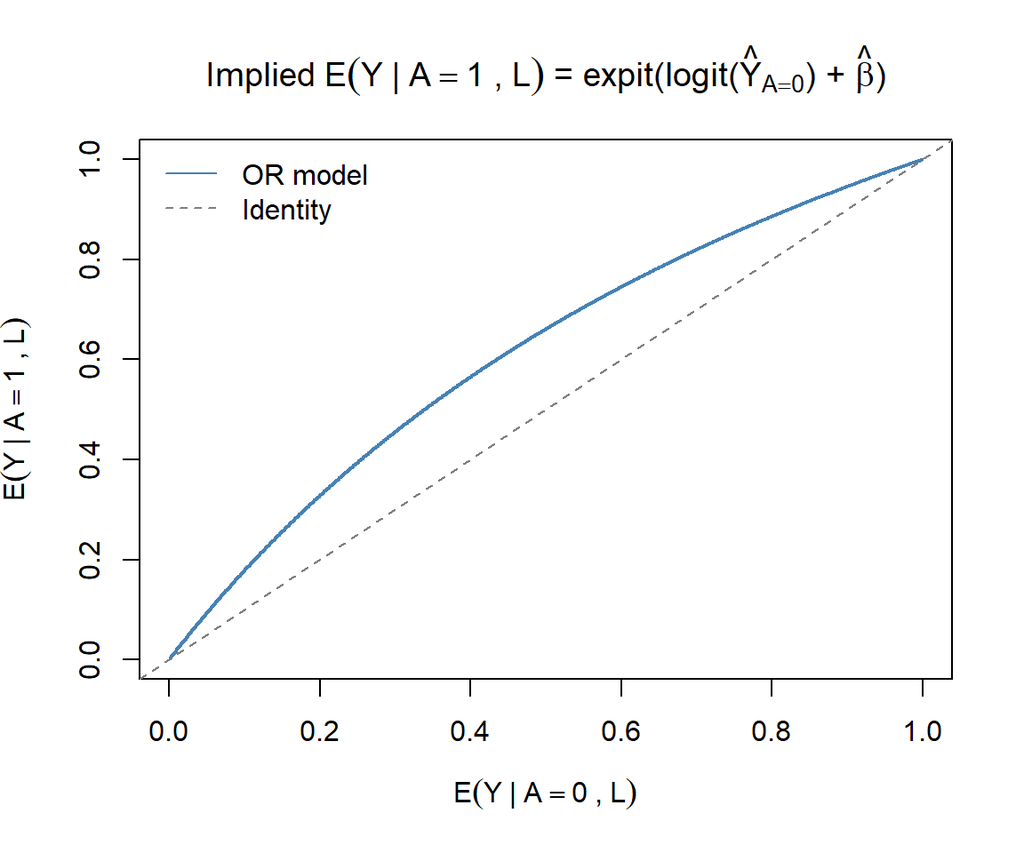

```r
p0_seq <- seq(0.001, 0.999, length.out = 1000)
p1_seq <- expit(logit(p0_seq) + beta_logit1)

plot(p0_seq, p1_seq, type = "l", col = "steelblue", lwd = 2,
     xlab = expression(E(Y ~ "|" ~ A == 0 ~ "," ~ L)),
     ylab = expression(E(Y ~ "|" ~ A == 1 ~ "," ~ L)),
     main = expression("Implied" ~ E(Y ~ "|" ~ A == 1 ~ "," ~ L) ~
                         "= expit(logit(" * hat(Y)[A==0] * ") + " * hat(beta) * ")"))
abline(0, 1, col = "gray50", lty = 2)
legend("topleft", legend = c("OR model", "Identity"),
       col = c("steelblue", "gray50"), lty = c(1, 2), bty = "n")
```

## 9. Summary of Results

```r
summary_all <- tibble(
  Exposure = rep(c("First Steps", "Maternal Age"), each = 3),
  Scale    = rep(c("Risk Difference", "Risk Ratio", "Odds Ratio"), times = 2),
  Estimate = c(beta_rd1_eif,  exp(beta_log1),  exp(beta_logit1),
               beta_rd3_eif,  exp(beta_log2),  exp(beta_logit2)),
  SE       = c(se_rd1_eif,    se_log1,         se_logit1,
               se_rd3_eif,    se_log2,         se_logit2),
  Null     = rep(c(0, 1, 1), 2)
) %>%
  mutate(
    CI_Lower = if_else(Scale == "Risk Difference",
                       Estimate - 1.96 * SE,
                       exp(log(Estimate) - 1.96 * SE)),
    CI_Upper = if_else(Scale == "Risk Difference",
                       Estimate + 1.96 * SE,
                       exp(log(Estimate) + 1.96 * SE))
  )

knitr::kable(
  summary_all %>% select(-Null) %>% mutate(across(where(is.numeric), ~round(.x, 4))),
  caption = "Summary — all assumption-lean regression results"
)
```

Summary — all assumption-lean regression results

| Exposure | Scale | Estimate | SE | CI_Lower | CI_Upper |
| --- | --- | --- | --- | --- | --- |
| First Steps | Risk Difference | 0.0053 | 0.0145 | -0.0231 | 0.0338 |
| First Steps | Risk Ratio | 1.9272 | 0.4299 | 0.8298 | 4.4758 |
| First Steps | Odds Ratio | 1.9508 | 0.4422 | 0.8200 | 4.6410 |
| Maternal Age | Risk Difference | 0.0011 | 0.0010 | -0.0008 | 0.0030 |
| Maternal Age | Risk Ratio | 1.0218 | 0.0199 | 0.9827 | 1.0625 |
| Maternal Age | Odds Ratio | 1.0228 | 0.0209 | 0.9818 | 1.0656 |

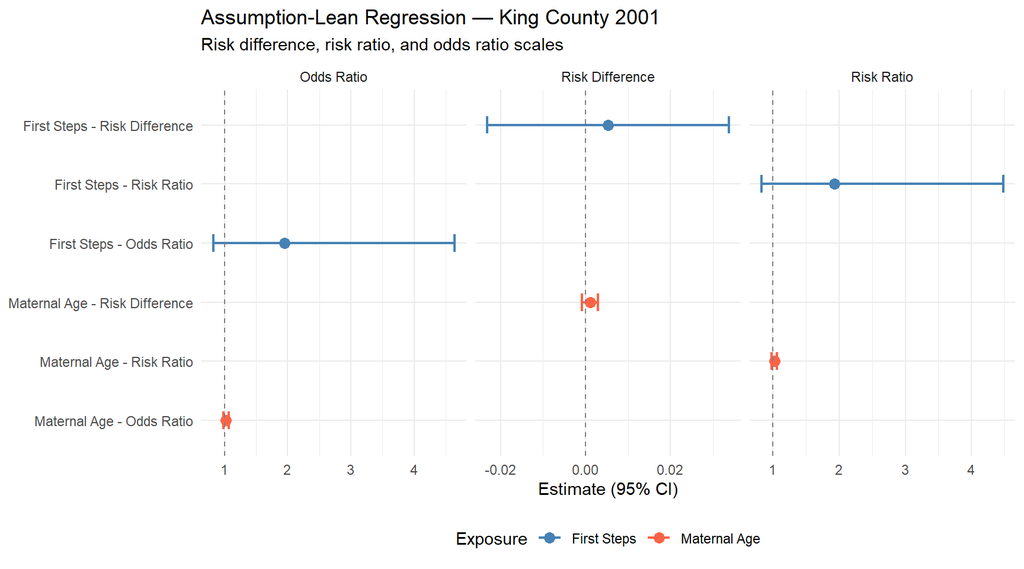

```r
summary_all %>%
  mutate(Label = factor(paste(Exposure, "-", Scale),
                        levels = rev(unique(paste(Exposure, "-", Scale))))) %>%
  ggplot(aes(x = Estimate, y = Label, color = Exposure)) +
  geom_point(size = 3) +
  geom_errorbarh(aes(xmin = CI_Lower, xmax = CI_Upper), height = 0.3, linewidth = 0.8) +
  geom_vline(aes(xintercept = Null), linetype = "dashed", color = "gray50") +
  facet_wrap(~Scale, scales = "free_x", nrow = 1) +
  scale_color_manual(values = c("steelblue", "tomato")) +
  labs(x = "Estimate (95% CI)", y = NULL, color = "Exposure",
       title = "Assumption-Lean Regression — King County 2001",
       subtitle = "Risk difference, risk ratio, and odds ratio scales") +
  theme_minimal() +
  theme(legend.position = "bottom")
```